# DS7331_Lab-3_Unsupervised

Of the customers who are in the “Yes” Churn category, more customers are within their first year of service, than the other 3 categories combined. We can examine this for the 4 different categories as well to verify this

```r
# Tenure Category for only Churn = Yes Customers
churn.df[churn.df$Churn == "Yes", ] %>% count(tenureCat)
```

```
## # A tibble: 4 x 2
##   tenureCat        n
##   <fct>        <int>
## 1 Under_1_Year   999
## 2 1_to_2_Years   309
## 3 2_to_4_Years   339
## 4 Over_4_Years   222
```

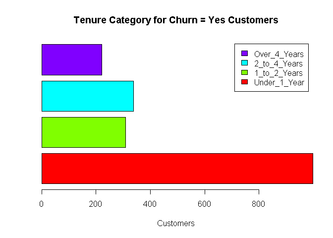

```r
# Plot of Tenure Categories for only Churn = Yes Customers

barplot( (churn.df[churn.df$Churn == "Yes", ] %>% count(tenureCat))$n,
        horiz = T,
        legend.text = (churn.df[churn.df$Churn == "Yes", ] %>% count(tenureCat))$tenureCat,
        col = rainbow(4),
        main = "Tenure Category for Churn = Yes Customers",
        xlab = "Customers")
```

**Examining Monthly Charges Categories by Churn**

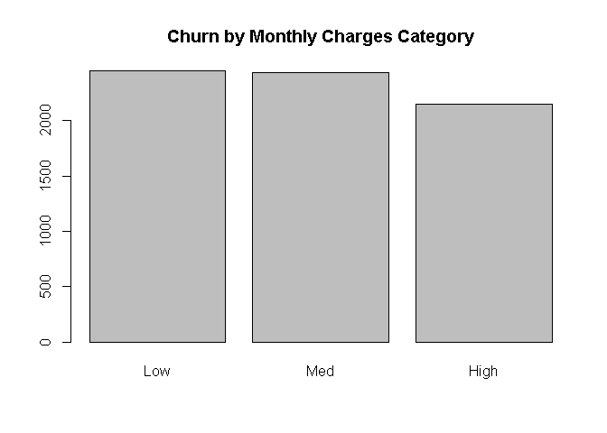

```r
# plot of monthlyCat

plot(churn.df$monthlyCat,
     main = "Churn by Monthly Charges Category")
```

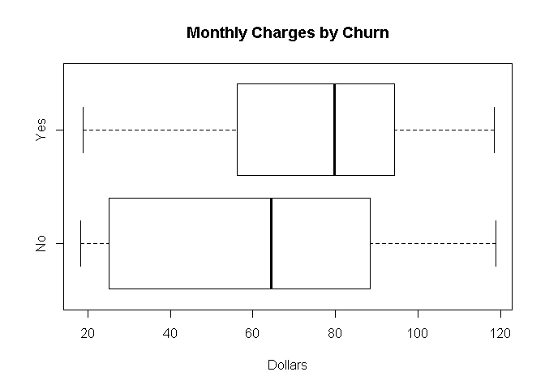

```r
# Comparing Monthly Charges by different Churn levels
boxplot(churn.df$MonthlyCharges ~ churn.df$Churn,
        main = "Monthly Charges by Churn",
        horizontal = T,
        xlab = "Dollars" )
```

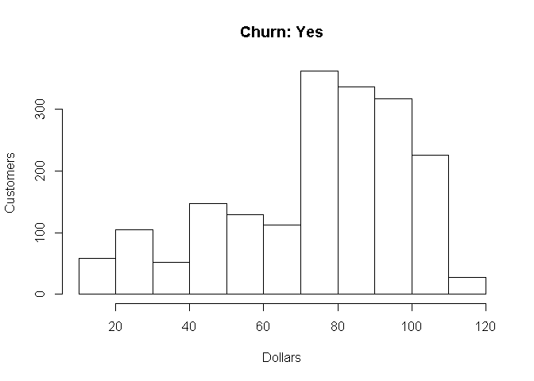

```r
# Historgram of of Monthly Charges for Churn = Yes Customers
hist(churn.df[churn.df$Churn == "Yes","MonthlyCharges"],
     #breaks = c(0,12,24,36,48,60,72),
     main = "Churn: Yes",
     xlab = "Dollars",
     ylab = "Customers")
```

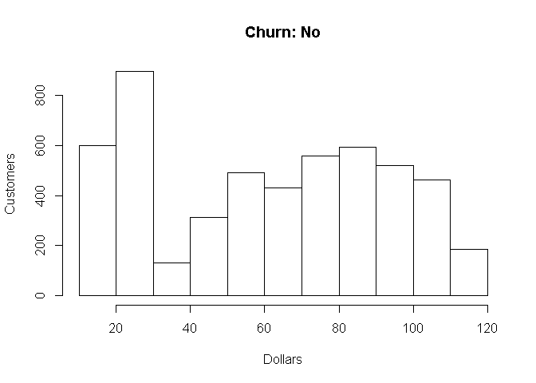

```r
# Historgram of of Monthly Charges for Churn = No Customers
hist(churn.df[churn.df$Churn == "No","MonthlyCharges"],
     #breaks = c(0,12,24,36,48,60,72),
     main = "Churn: No",
     xlab = "Dollars",
     ylab = "Customers")
```

###Streaming Media

Quickly examining the customer profiles, we can see of the 5517 customers who have internet, 767 stream TV but do *NOT* stream movies. And 792 of them stream movies, but not TV. So in both cases around 14% only stream one or the other.

This may be due to different device profiles with more specific use cases. For example cable services bundled with a fiber circuit connecting to a family’s home PC, vs a single / bachelor connecting to a gaming console like an Xbox or Playstation.

Unfortunately we do not have device information to further interpret these attributes

```r
# comparing StreamingMovies vs StreamingTV
table(churn.df[,c("StreamingMovies","StreamingTV")])
```

```
##                      StreamingTV
## StreamingMovies         No No internet service  Yes
##   No                  2018                   0  767
##   No internet service    0                1526    0
##   Yes                  792                   0 1940
```

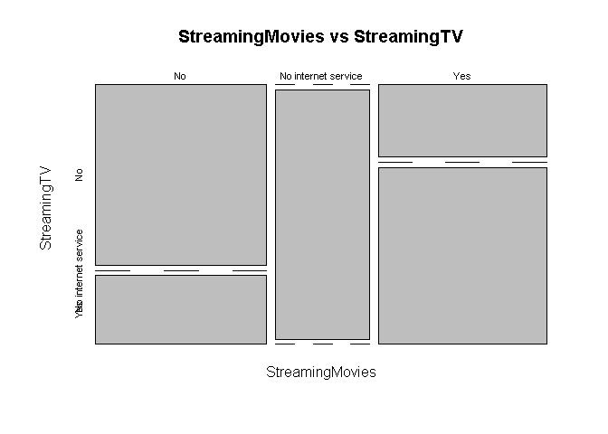

```r
plot(table(churn.df[,c("StreamingMovies","StreamingTV")]),
     main = "StreamingMovies vs StreamingTV")
```

###Advanced Services

Looking at some of the advanced services we can also do a similar breakdown. The numbers are output in the code below, but essentially this further infers there are different device types. Using the scenario above, device protection would not be a need for a home PC warrantied by Dell or HP. However, for a tablet or cell phone it would be more applicable.

```r
# comparing OnlineBackup vs OnlineSecurity
table(churn.df[,c("OnlineBackup","OnlineSecurity" )])
```

```
##                      OnlineSecurity
## OnlineBackup            No No internet service  Yes
##   No                  2195                   0  893
##   No internet service    0                1526    0
##   Yes                 1303                   0 1126
```

```r
table(churn.df[,c("OnlineBackup","DeviceProtection" )])
```

```
##                      DeviceProtection
## OnlineBackup            No No internet service  Yes
##   No                  1984                   0 1104
##   No internet service    0                1526    0
##   Yes                 1111                   0 1318
```

```r
table(churn.df[,c("DeviceProtection","OnlineSecurity" )])
```

```
##                      OnlineSecurity
## DeviceProtection        No No internet service  Yes
##   No                  2187                   0  908
##   No internet service    0                1526    0
##   Yes                 1311                   0 1111
```

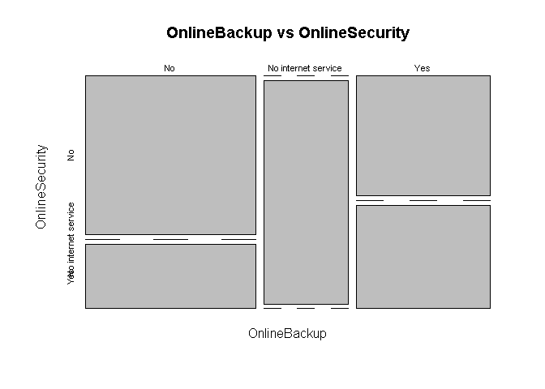

```r
plot(table(churn.df[,c("OnlineBackup","OnlineSecurity")]),
     main = "OnlineBackup vs OnlineSecurity")
```

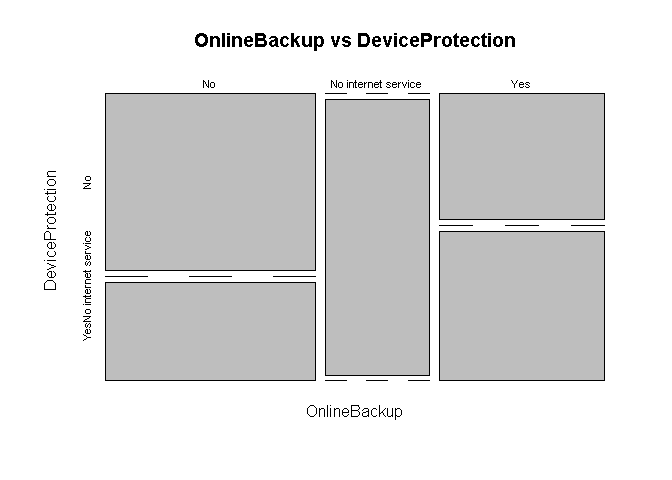

```r
plot(table(churn.df[,c("OnlineBackup","DeviceProtection")]),
     main = "OnlineBackup vs DeviceProtection")
```

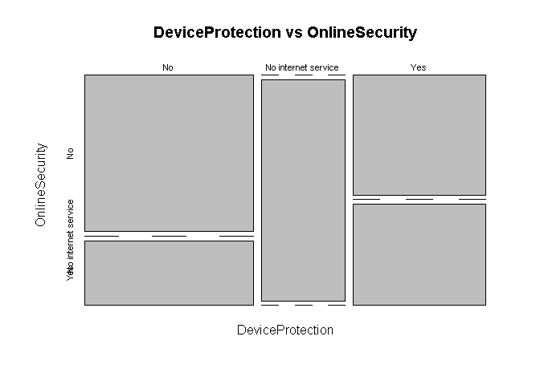

```r
plot(table(churn.df[,c("DeviceProtection","OnlineSecurity")]),
     main = "DeviceProtection vs OnlineSecurity")
```

###EDA CONCLUSION

Just by visually examining the features such as who uses device protection vs online backup vs online security, its difficult to build a customer profile or show assocation across these services

Thus a more advanced technique is needed

## Unsupervised Learning: Clustering

Unlike supervised machine learning, where the outcomes are already known, with unsupervised you take a data and try to discern any patterns or groups, without necessarily having a prediction to model.

**Method Selection**

The method chosen for this exercise was hierarchical clustering. It is one of the more foundational clustering methods, lends itself well to visualization, even for categorical data.

### Challenges With Mixed and Categorical Data

While it is quite easy to imagine distances between numerical data points using Eucledian distances, categorical data does not seem so obvious. Thus we need a method to score similarity of each individual observation with respect to the categorical parameters. In order to do that, one of the first steps we need to do is create a **dissimilarity** matrix

On a final note, when doing clustering it is ideal if all the data is either categorical or numerical. Clustering on mixed data is an advanced techique beyond the scope of this class. Fortunately we have already done this step earlier for our exploratory data anlaysis

NOTE ON ALTERNATIVE METHOD

An alternative method, known as **K-Mode** which is an adaptation of the **K-Means** clustering method using the modes of categorical attributes instead the mean. Ultimately decided not to go this route, given the limited package availability and available content coverage. It is a more advanced technique, and if interested take a look at the klaR package:

https://cran.r-project.org/web/packages/klaR/ https://www.youtube.com/watch?v=b39_vipRkUo

**Prepping Data For Clustering**

Our goal is to really examine what services would benefit or entice our customers, so we want to focus on those aspects.

As before we need to prevent data leakage for information we wouldn’t necessarily have, specifically if the customer churns, as well as what their total spend would be. Their monthly spend however is something we would know for the current month, thus we will leave that factor in the analysis to help determine if they are cost conscious or not. Additionally tenure will remain, as we can know how long the customer been with us at the point in time. Contract itself may be a secondary business outcome, tied to tenure, thus we will not include it WITH tenure, as the dependency may skew our results. Lastly the payment method and the paperless billing do not have much business value.

```r
# exclude Contract, PaperlessBilling, PaymentMethod, TotalCharges, Churn
churn.df %>% dplyr::select(-c('Contract', 'PaperlessBilling', 'PaymentMethod', 'TotalCharges', 'Churn','tenure','MonthlyCharges'))  -> churncluster.df
```

###Gower: Dissimilarity Matrix Calculation

Before we can start the actual clustering, we need to construct a **Gower Matrix.** The handling of nominal, ordinal, and binary data is achieved by using this general dissimilarity coefficient of Gower. While numerical and rank data is conceptually easier to understand [as with most clustering methods], categorical data is till possible.

Gower distance is calculated for each variable type and scaled between 0 and 1, and then a linear combination is calculated to create the final matrix. Additionally user-defined weights can be specified.

Variables are essentially expanded into a binary or “dummy variable” format. I.e. * Internet_DSL: 0 or 1 * Internet_Fiber: 0 or 1 * Internet_NO: implied by 0’s in both the prior categories

It then computes some measure for those variables [also known as the “Dice Coefficient”] based on the differences of those individuals. Note that the theory is beyond the scope of this notebook, but essentially a series of matrix operations that examines the relative agreement, where you a put 0 when both individuals fall into the same category and a 1 if they don’t. Thus the higher the value, the more *dissimilar*

Look at the links below if interested

https://stats.stackexchange.com/questions/297121/measures-of-association-between-nominal-variables-with-the-same-categories-pair/297206#297206

https://stats.stackexchange.com/questions/55798/what-is-the-optimal-distance-function-for-individuals-when-attributes-are-nomina/55802#55802

https://stats.stackexchange.com/questions/15287/hierarchical-clustering-with-mixed-type-data-what-distance-similarity-to-use/15313#15313

###/! CPU WARNING This entire process requires an n x m distance matrix to be calculated. For this particular dataset, CRAN [i.e. non-parallelized R] can take from 20-45 minutes depending on your CPU, RAM, and HD IOPS / throughput.

```r
###Gower Calculation

# available metric options are: c("euclidean", "manhattan", "gower")
churngower.dist <- daisy(churncluster.df, metric = c("gower"))

# class(churngower.dist)

# store as matrix
as.matrix(churngower.dist) -> churngower.mtx
```

As a sanity check, we can print out the most similar and dissimilar pair in the data to see if it makes sense

**Most Similar Pair**

```r
#most similar pair

churncluster.df[which(churngower.mtx == min(churngower.mtx[churngower.mtx != min(churngower.mtx)] ), arr.ind = T )[1,],  ]
```

```
##     gender SeniorCitizen Partner Dependents PhoneService    MultipleLines
## 181 Female            No      No         No           No No phone service
## 1   Female            No     Yes         No           No No phone service
##     InternetService OnlineSecurity OnlineBackup DeviceProtection
## 181             DSL             No          Yes               No
## 1               DSL             No          Yes               No
##     TechSupport StreamingTV StreamingMovies    tenureCat monthlyCat
## 181          No          No              No Under_1_Year        Low
## 1            No          No              No Under_1_Year        Low
```

**Most Dissimilar Pair**

```r
#most DISsimilar pair

churncluster.df[which(churngower.mtx == max(churngower.mtx[churngower.mtx != max(churngower.mtx)] ), arr.ind = T )[1,],  ]
```

```
##    gender SeniorCitizen Partner Dependents PhoneService    MultipleLines
## 73   Male           Yes     Yes        Yes          Yes              Yes
## 1  Female            No     Yes         No           No No phone service
##    InternetService OnlineSecurity OnlineBackup DeviceProtection
## 73     Fiber optic            Yes           No              Yes
## 1              DSL             No          Yes               No
##    TechSupport StreamingTV StreamingMovies    tenureCat monthlyCat
## 73         Yes         Yes             Yes Over_4_Years       High
## 1           No          No              No Under_1_Year        Low
```

##Hierarchical Clustering

For this notebook we will focus on hierarchical clustering as it lends itself to visual analysis, and thus more intuitive understanding. We will be comparing the agglomerative (bottom-up) and divisive (top-down) methods of Hierarchical and noting differences in the results

**Agglomerative** clustering starts with as many clusters as there are observations, with each of those observations being its own individual cluster. Then as we model, it progressively finds more *similar* data points and groups them into clusters.

Conversely, **divisive** clustering assumes all data points are part of a single cluster, and then subdivides them by most *dissimilar* ones into separate clusters.

In general, divisive is better for a smaller number of large clusters, while agglomerative is better for finding a large number of smaller clusters

### Agglomerative Hierarchical Cluster

**DETERMINE HIERARCHICAL CLUSTER DISTANCE**

4 methods determine cluster distance

- **COMPLETE**: pairwise similarty between ALL observations in clusters 1 and 2. Uses LARGEST distance as distance between clusters. NOTE: this is the *default* method.
- **SINGLE**: as per COMPLETE but uses SMALLEST distance
- **AVERAGE**: as per COMPLETE but takes AVERAGE distance
- **CENTROID**: calculates centroid of each cluster and uses CENTROID DISTANCE

NOTE: COMPLETE & AVERAGE produce more “balanced” trees, thus for the purpose of this exercise we will be using **Complete**

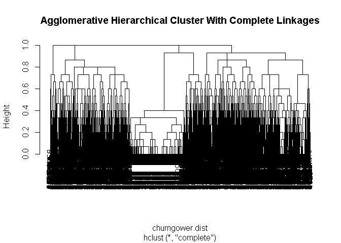

```r
# Agglomerative clustering
churn.hclust.agg <- hclust(churngower.dist, method = "complete")
# hclust method = c('complete','average','single')
plot(churn.hclust.agg, main = "Agglomerative Hierarchical Cluster With Complete Linkages")
```

### Divisive Complete Hierarchical Cluster

**/! CPU WARNING** The Divisive is much more time intensive. Expect 20-30+ minutes

[figure not shown]

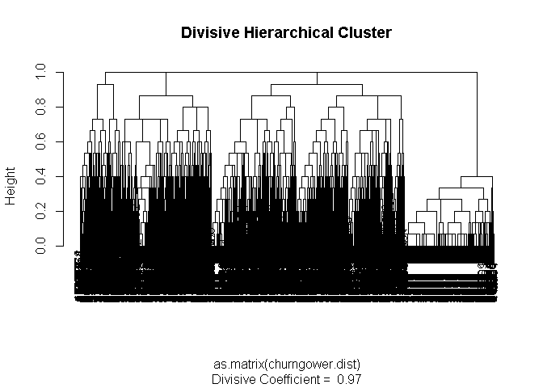

```r
# Divisive clustering
churn.hclust.div <- diana(as.matrix(churngower.dist),
                  diss = TRUE,
                  keep.diss = TRUE)
plot(churn.hclust.div, main = "Divisive Hierarchical Cluster")
```

While we can see the tree itself, its not very intuitive to understand how many potential clusters we should divide this into. We do note one group definitely stands out, and this is likely the 1526 users who have no interenet service. However, other than this, no clear grouping presents itself

Thus we need to decide how many clusters in which to group

##Cluster Evaluation Methods

**/! CPU WARNING** Expect 30+ minutes

```r
library(fpc)

cstats.table <- function(dist, tree, k) {
clust.assess <- c("cluster.number","n","within.cluster.ss","average.within","average.between",
                  "wb.ratio","dunn2","avg.silwidth")
clust.size <- c("cluster.size")
stats.names <- c()
row.clust <- c()
output.stats <- matrix(ncol = k, nrow = length(clust.assess))
cluster.sizes <- matrix(ncol = k, nrow = k)
for(i in c(1:k)){
  row.clust[i] <- paste("Cluster-", i, " size")
}
for(i in c(2:k)){
  stats.names[i] <- paste("Test", i-1)

  for(j in seq_along(clust.assess)){
    output.stats[j, i] <- unlist(cluster.stats(d = dist, clustering = cutree(tree, k = i))[clust.assess])[j]

  }

  for(d in 1:k) {
    cluster.sizes[d, i] <- unlist(cluster.stats(d = dist, clustering = cutree(tree, k = i))[clust.size])[d]
    dim(cluster.sizes[d, i]) <- c(length(cluster.sizes[i]), 1)
    cluster.sizes[d, i]

  }
}
output.stats.df <- data.frame(output.stats)
cluster.sizes <- data.frame(cluster.sizes)
cluster.sizes[is.na(cluster.sizes)] <- 0
rows.all <- c(clust.assess, row.clust)

# rownames(output.stats.df) <- clust.assess
output <- rbind(output.stats.df, cluster.sizes)[ ,-1]
colnames(output) <- stats.names[2:k]
rownames(output) <- rows.all
is.num <- sapply(output, is.numeric)
output[is.num] <- lapply(output[is.num], round, 2)
output
}
```

###Stats for Divisive Cluster

```r
## DIVISIVE STATS
# capping the maximum amout of clusters at 6

stats.df.div <- cstats.table(churngower.dist, churn.hclust.div, 6)
stats.df.div
```

```
##                    Test 1  Test 2  Test 3  Test 4  Test 5
## cluster.number       2.00    3.00    4.00    5.00    6.00
## n                 7043.00 7043.00 7043.00 7043.00 7043.00
## within.cluster.ss 1106.43  995.10  544.71  527.39  417.47
## average.within       0.54    0.52    0.38    0.38    0.32
## average.between      0.63    0.60    0.64    0.64    0.62
## wb.ratio             0.85    0.87    0.60    0.59    0.51
## dunn2                1.17    0.99    1.23    1.12    1.17
## avg.silwidth         0.16    0.12    0.32    0.29    0.32
## Cluster- 1  size   685.00  685.00  685.00  473.00  473.00
## Cluster- 2  size  6358.00 1549.00 1549.00 1549.00 1549.00
## Cluster- 3  size     0.00 4809.00 3283.00 3283.00 1440.00
## Cluster- 4  size     0.00    0.00 1526.00 1526.00 1843.00
## Cluster- 5  size     0.00    0.00    0.00  212.00 1526.00
## Cluster- 6  size     0.00    0.00    0.00    0.00  212.00
```

###Stats for Agglomerative Cluster

```r
## AGGLOMERATIVE STATS
# capping the maximum amout of clusters at 6
stats.df.aggl <-cstats.table(churngower.dist, churn.hclust.agg, 6)
stats.df.aggl
```

```
##                    Test 1  Test 2  Test 3  Test 4  Test 5
## cluster.number       2.00    3.00    4.00    5.00    6.00
## n                 7043.00 7043.00 7043.00 7043.00 7043.00
## within.cluster.ss 1181.41  975.31  686.29  648.77  604.30
## average.within       0.55    0.51    0.40    0.39    0.37
## average.between      0.63    0.61    0.63    0.62    0.61
## wb.ratio             0.88    0.85    0.64    0.62    0.61
## dunn2                1.14    1.09    1.23    1.06    1.06
## avg.silwidth         0.11    0.14    0.25    0.21    0.19
## Cluster- 1  size  6870.00 4893.00 2033.00 2033.00 2033.00
## Cluster- 2  size   173.00 1977.00 2860.00 2592.00 1183.00
## Cluster- 3  size     0.00  173.00 1977.00 1977.00 1409.00
## Cluster- 4  size     0.00    0.00  173.00  268.00 1977.00
## Cluster- 5  size     0.00    0.00    0.00  173.00  268.00
## Cluster- 6  size     0.00    0.00    0.00    0.00  173.00
```

###Selecting Number of Clusters

**Elbow method:** start with it when the compactness of clusters, or similarities within groups are most important for your analysis.

**Silhouette method:** as a measure of data consistency, the silhouette plot displays a measure of how close each point in one cluster is to points in the neighboring clusters.

### Elbow Plot for Divisive Clustering

Given the sharp change, 4 clusters appears to be the best choice

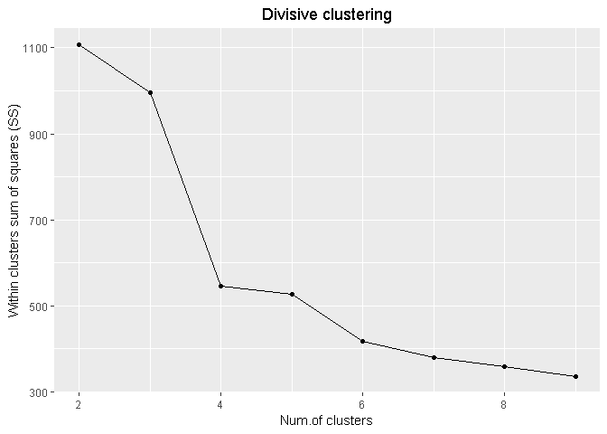

```r
# Elbow for Divisive clustering
ggplot(data = data.frame(t(cstats.table(churngower.dist, churn.hclust.div, 9))),
  aes(x=cluster.number, y=within.cluster.ss)) +
  geom_point()+
  geom_line()+
  ggtitle("Divisive clustering") +
  labs(x = "Num.of clusters", y = "Within clusters sum of squares (SS)") +
  theme(plot.title = element_text(hjust = 0.5))
```

### Elbow Plot for Agglomerative Clustering

Given the sharp change, 4 clusters appears to be the best choice

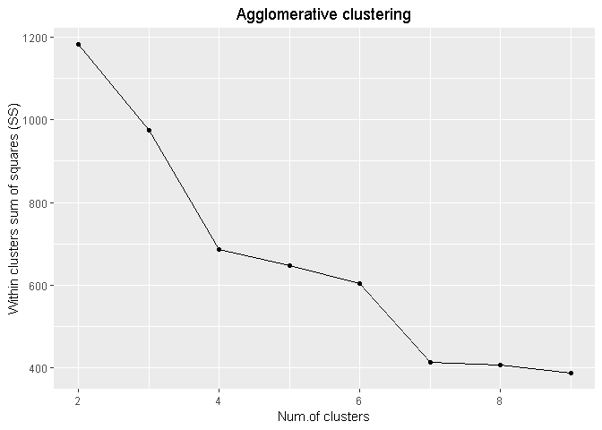

```r
# Elbow for Agglomerative clustering
ggplot(data = data.frame(t(cstats.table(churngower.dist, churn.hclust.agg, 9))),
  aes(x=cluster.number, y=within.cluster.ss)) +
  geom_point()+
  geom_line()+
  ggtitle("Agglomerative clustering") +
  labs(x = "Num.of clusters", y = "Within clusters sum of squares (SS)") +
  theme(plot.title = element_text(hjust = 0.5))
```

### Silhouette for Agglomerative clustering

When it comes to silhouette assessment, the rule is you should choose the number that maximizes the silhouette coefficient because you want clusters that are distinctive (far) enough to be considered separate.

The silhouette coefficient ranges between -1 and 1, with 1 indicating good consistency within clusters, -1 — not so good. From the plot below, 7 clusters would be preferred, 4 being the second choice

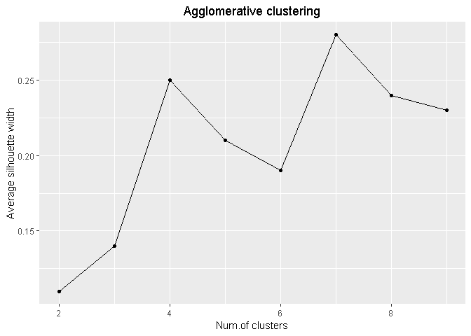

```r
# Silhouette for Agglomerative clustering
ggplot(data = data.frame(t(cstats.table(churngower.dist, churn.hclust.agg, 9))),
  aes(x=cluster.number, y=avg.silwidth)) +
  geom_point()+
  geom_line()+
  ggtitle("Agglomerative clustering") +
  labs(x = "Num.of clusters", y = "Average silhouette width") +
  theme(plot.title = element_text(hjust = 0.5))
```

### Silhouette for Divisive Clustering

From the plot below, 4 clusters would be preferred

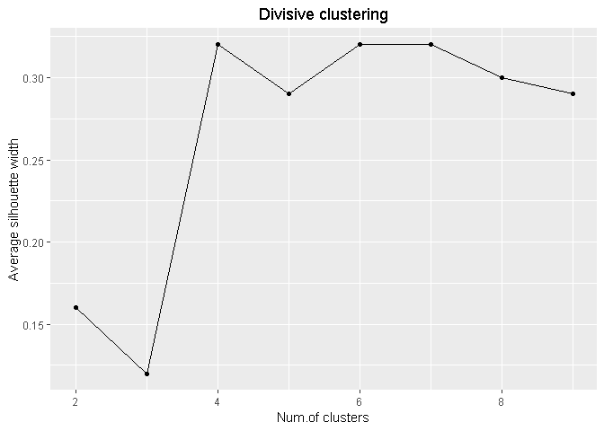

```r
# Silhouette for Divisive Clustering
ggplot(data = data.frame(t(cstats.table(churngower.dist, churn.hclust.div, 9))),
  aes(x=cluster.number, y=avg.silwidth)) +
  geom_point()+
  geom_line()+
  ggtitle("Divisive clustering") +
  labs(x = "Num.of clusters", y = "Average silhouette width") +
  theme(plot.title = element_text(hjust = 0.5))
```

##Conclusion

Given that most of the evaluation techniques favored 4 clusters, this is what we will go with. Again there is no “right” answer here, and it makes more business sense to have fewer clusters, at least initially, and thus we focus on experimenting with targeted marketing

###Visual for Agglomerative Clustering

Now that we have 4 clusters selected, lets look at this graph again, with each of the clusters colored separately.

**Colored Agglomerative Hierarchical**

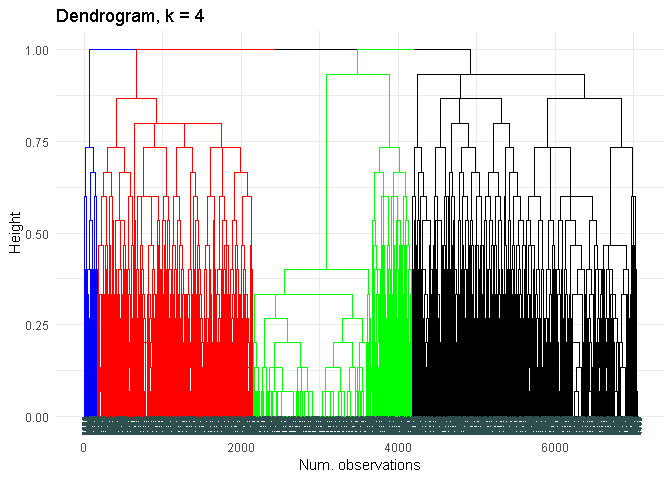

```r
# Visual for Agglomerative Clustering


#library("ggplot2")
#library("reshape2")
#library("purrr")
#library("dplyr")

# dendrogram starting point
library("dendextend")
dendro <- as.dendrogram(churn.hclust.agg)

#using 4 clusters as per Elbow and Silhouette
dendro.col <- dendro %>%
  set("branches_k_color", k = 4, value =   c("blue", "red", "green", "black")) %>%
  set("branches_lwd", 0.6) %>%
  set("labels_colors",
      value = c("darkslategray")) %>%
  set("labels_cex", 0.5)
ggd1 <- as.ggdend(dendro.col)
ggplot(ggd1, theme = theme_minimal()) +
  labs(x = "Num. observations", y = "Height", title = "Dendrogram, k = 4")
```

**Colored Divisive Hierarchical**

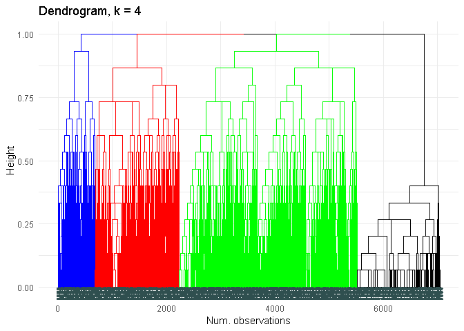

```r
# dendrogram starting point
# library("dendextend")

dendro <- as.dendrogram(churn.hclust.div)

#using 4 clusters as per Elbow and Silhouette
dendro.col <- dendro %>%
  set("branches_k_color", k = 4, value =   c("blue", "red", "green", "black")) %>%
  set("branches_lwd", 0.6) %>%
  set("labels_colors",
      value = c("darkslategray")) %>%
  set("labels_cex", 0.5)
ggd1 <- as.ggdend(dendro.col)
ggplot(ggd1, theme = theme_minimal()) +
  labs(x = "Num. observations", y = "Height", title = "Dendrogram, k = 4")
```

### COMPARE AGG & DIV HCLUST RESULTS IN TABLE

NOTE: Not going to actually execute this code, but will have here for reference

**Why a Table in R May Not Work**

Your first instince may be to output the cluster labels into vectors, and then put them into a table to compare as such:

*first create agg vector from cuttree* cutree(churn.hclust.agg, k = 4) -> churn.agg.cutree

*second create div vector from cuttree* cutree(churn.hclust.div, k = 4) -> churn.div.cutree

*then put into table* table(churn.agg.cutree, churn.div.cutree)

The issue is that cluster 1 in Agglomerative vs cluster 1 in Divisive do not necessarily mean the same thing.

**A Better Way**

Take the cluster labels, add them as separate fields in a new dataframe, then export them as a CSV. Here you can import them into tools like Excel or PowerBI, and do more analysis on this. The reason being you very likely need an SME to help you *interpret* the meaning of these clusters, and possibly fine tune them **from a business** perspective

The code below can help you do that

churnout.df <- churncluster.df churnout.df$agg <- churn.agg.cutree churnout.df$div <- churn.div.cutree write.csv(churnout.df , file = “d:/temp/data/mining/final/churnout.csv”, eol = “”, row.names = T, append = F)